# MUSA 508 - Homework 5

Jay Greene (Partner: Esther Yihan Zhang, Brian Rawn)

11/15/2020

## 1.1 Introduction

The following study was conducted to operationalize bike ride-sharing stations in Boston, Massachusetts. Boston has a city-wide goal of increasing bike usage by 400% by 2030. Towards that effort, the city has put substantial funding into infrastructure development of safer bike routes. The city has added an additional 50 new bikes share stations since 2019 and has held over 42 public meetings to determine where to add more. This study represents the kind of information that is necesary to facilitate public-private partnerships. Bluebikes is owned by the municipalities of Boston, Brookline, Cambridge, Somerville and Everet, but operated by a private company called Motivate. Analysis into this operation, therefore, would require a combination of publically availble data bout the spatial conditions of the bikeshare program, and data collected by the company on users. Becuase the program is publicly owned, Motivate publishes real-time data about the program’s use.

The purpose of this study was to predict the demand of bikes among boston-based bike stations. In addition to learning to use time-space predictive modeling to address operational challenges, we learned how nuanced insights into the capacity of predictive models can be used for business strategy.

This model can be used to develop both a pro-active bike operations strategy and re-active strategy. Proactively, were we have accurately predicted the demand of bikes, we can develop a resource-intensive strategy for meeting this demand. In practice, this could be trucks with pre-determined routes and staffing. For the times when we seem to be consistently under-predicting, wecould develop a more re-active stragey like surge-pricing to intice customers to redistribute the bikes as needed. Either way, predictive models help us identify both constants and unknowns in the process.

## 2.1 Setup

First, we will load relevant libraries and graphic themes.

## 2.2 Import Data

The bikeshare data was harvested by the bluebikes program and make public through the Analyze Boston dataplatform. We analyzed bikeshare data for April 2018.

Use date parsing to bin the data by 15 and 60 minute intervals

## 2.3 Import Census Information

Census geography and varaibles were collected using tidycensus package. Then, spatial information of rideshare data was joined to station origin.

## 2.4 Import Weather Data

Weather data from Boston International Airport (KBOS) was collected using reim_measures. The plots display percipitation, wind speed, adn temprarture on an hourly basis over the study period.

[figure not shown]

## 3.1 Describe and Explore the Data

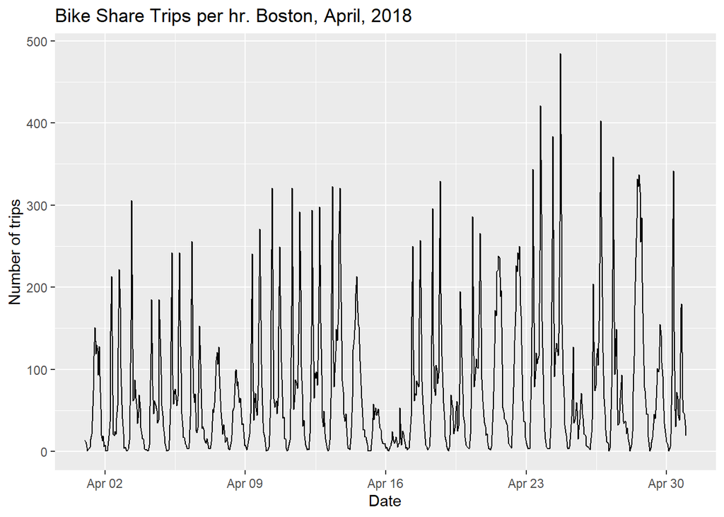

Next we examined the distribution of trip volume by station for different times of day. There appears to be significantly higher usage during the AM and PM rush.

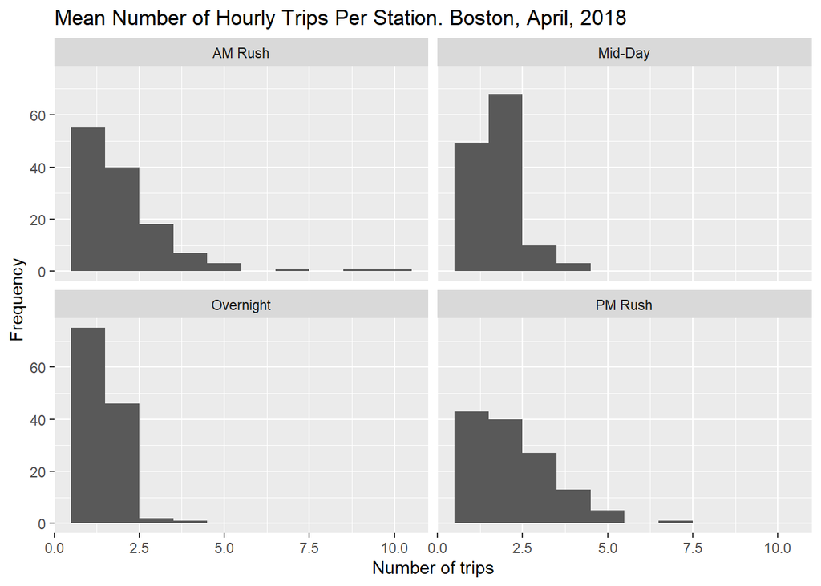

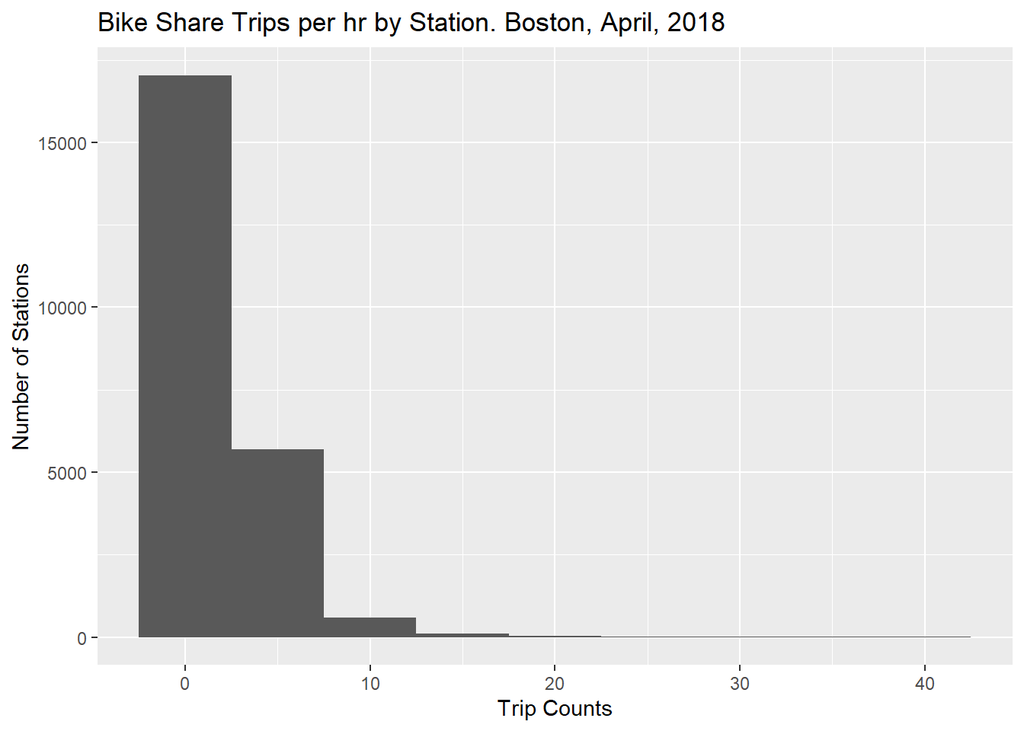

The following plots display bike share trips by day of the week and on weekend veruss weekday. Weekday patterns seem to follow similar patterns, with a spike in usage udring the AM and PM rush. Weekend appears to be a smoother distribution, with peak hours in the early afternoon. Overall usage is significantly lower on the weeekends.

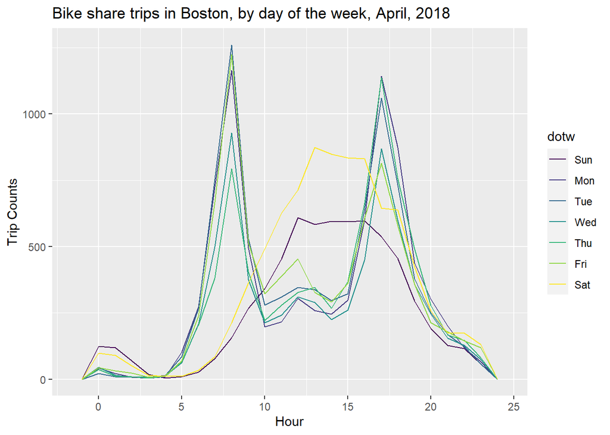

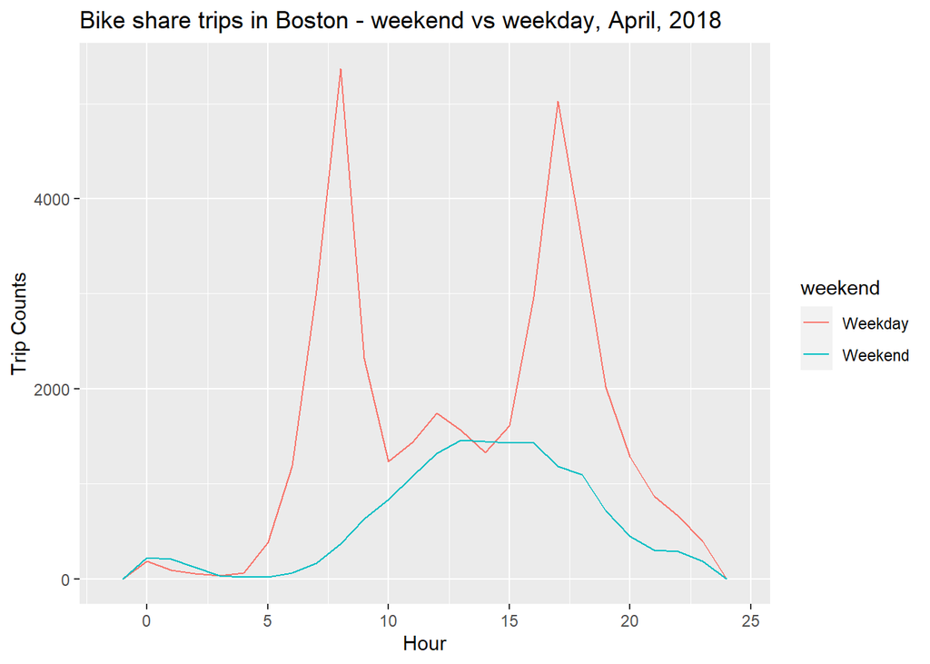

The plot below displays bike share trips per hour by station.The maps confirm the analysis above - weekday AM and PM rushes are seen to be concentrated in the downtown commercial districts. Weekend use is more evenly distrubted throughout the day, and throughout residential areas.

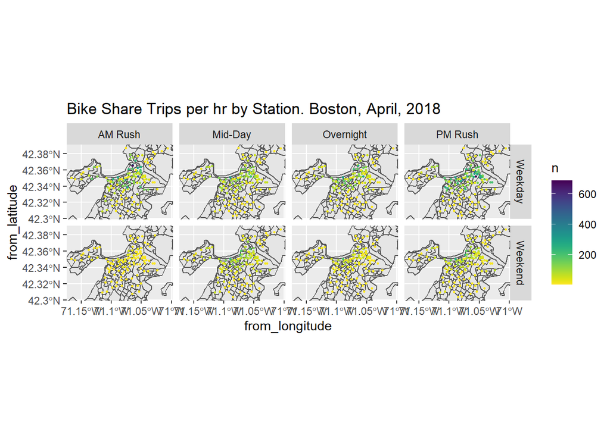

## 3.2. Create Time-Space Panel

We then make sure each unique station and hour/day combo exists in our dataset. we created a panel data set where each time period in the study is represented by a row.

We create the full panel which summarizes counts by station for each time internal and remove station IDs that are FALSE.

This animated map shows usage overtime. heavy concentration of rides are seen to occur during AM and PM rushes in the downtown commercial district.

```
## nframes and fps adjusted to match transition
```

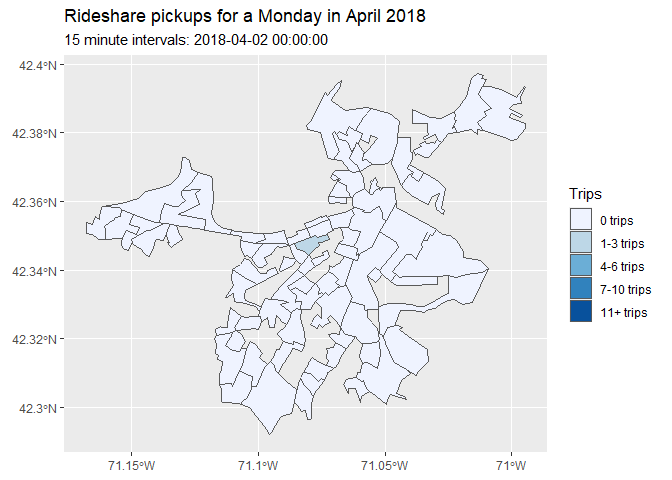

```r
rideshare_animation <-
  ggplot() +
    geom_sf(data = ride.animation.data, aes(fill = Trips)) +
    scale_fill_manual(values = palette5) +
    labs(title = "Rideshare pickups for a Monday in April 2018",
         subtitle = "15 minute intervals: {current_frame}") +
    transition_manual(interval15)


animate(rideshare_animation, duration=20, renderer = gifski_renderer())
```

## 3.3. Create time lags

Creating time lag variables. We controled for the effects of the Easter Holiday (April 1st) and for dummy lag variables indicated temporal proximity to the holiday.

## 3.4 Other Features

### 3.4.1 Time Features

A feature was created to account for weekend versus weekday use.

### 3.4.2 Spatial Features

Input Nearest neighbor function for analyis of neighborhood spatial characteristics.

Create feature for distance to water and parkways.

Create feature to see See if the destination is within the 100m buffer of parks larger than 15 acres.

Create categorical variable for distance to colleges and universities.

Join new features to ride.panel

## 4.1 Run Models

We then split our data into a training and a test set set and train the model on the data from the first two weeks of april. We split the data by time and not randomly becuase of the temporal relationship of demand.

## 4.2. Predict for test data

After the models have fun, we create a nested data frame to test data by week.

Create a function called `model_pred`

Run Predictions

## 5.1. Examine Error Metrics for Accuracy

Plot Mean Absolute Errors by model spec and week

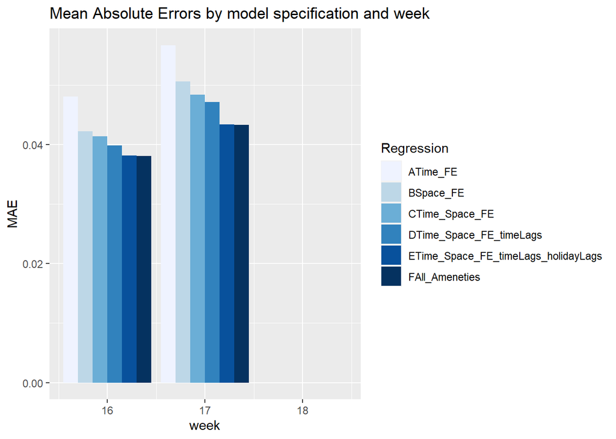

Plot Predicted/Observed Bike share time series. We seem to be consistently under predicting the data in all models.

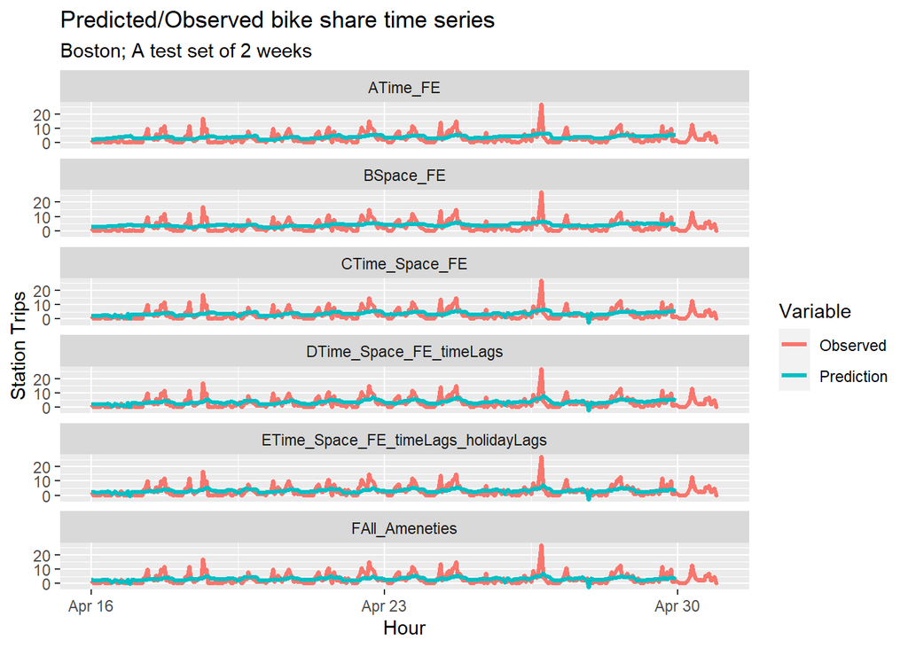

Plot Mean Absolute Errors by station

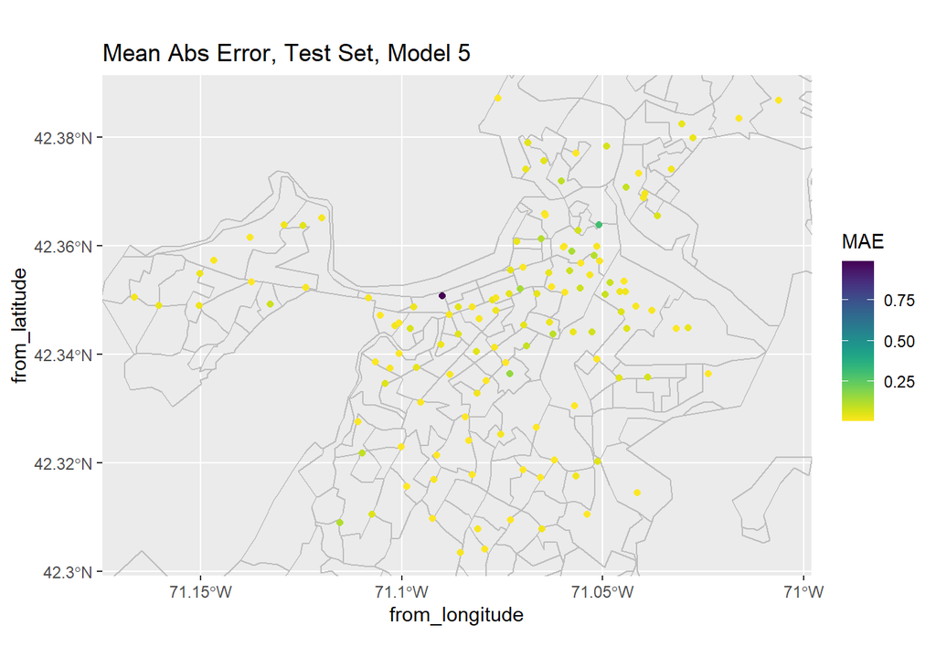

## 5.2. Space-Time Error Evaluation

plot observed vs. predicted for different times of day during the week and weekend

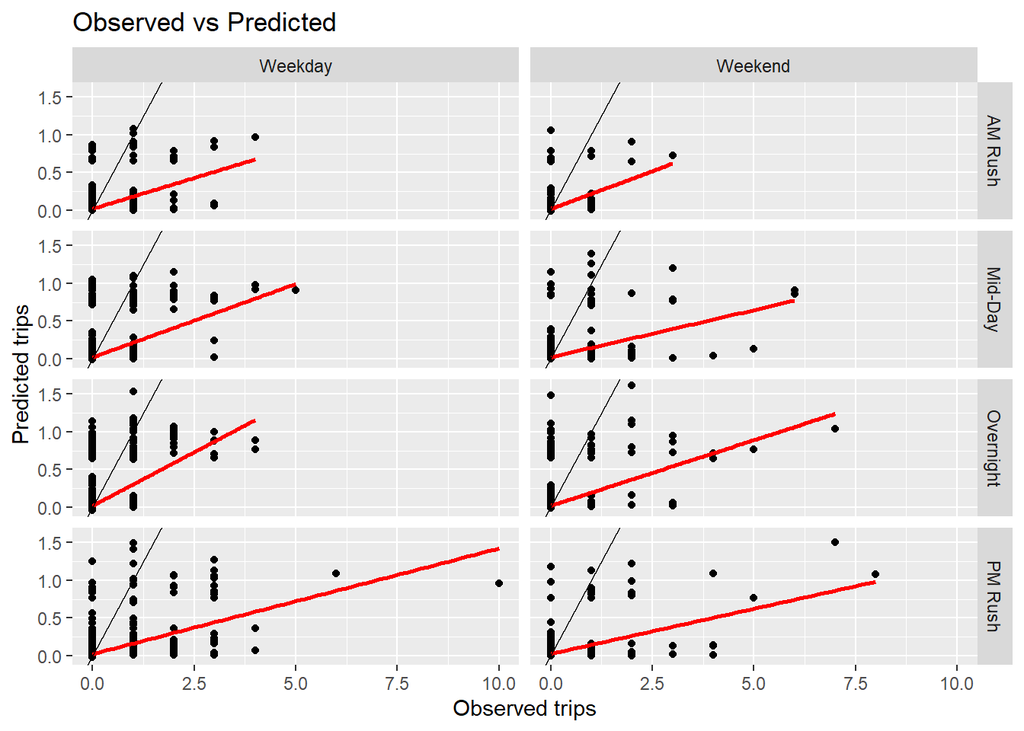

Plot errors on a map by weekend/weekday and time of day. There appears to be some spatial clustering of errors. Based on the location of the errors, they are occuring in an area with a high number of hospitals. Perhaps we have not adequately accounted for the higher demand in statations near hospitals.

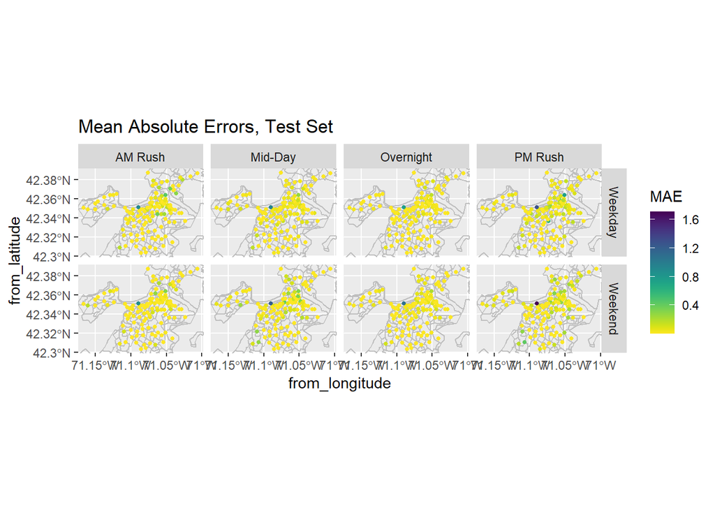

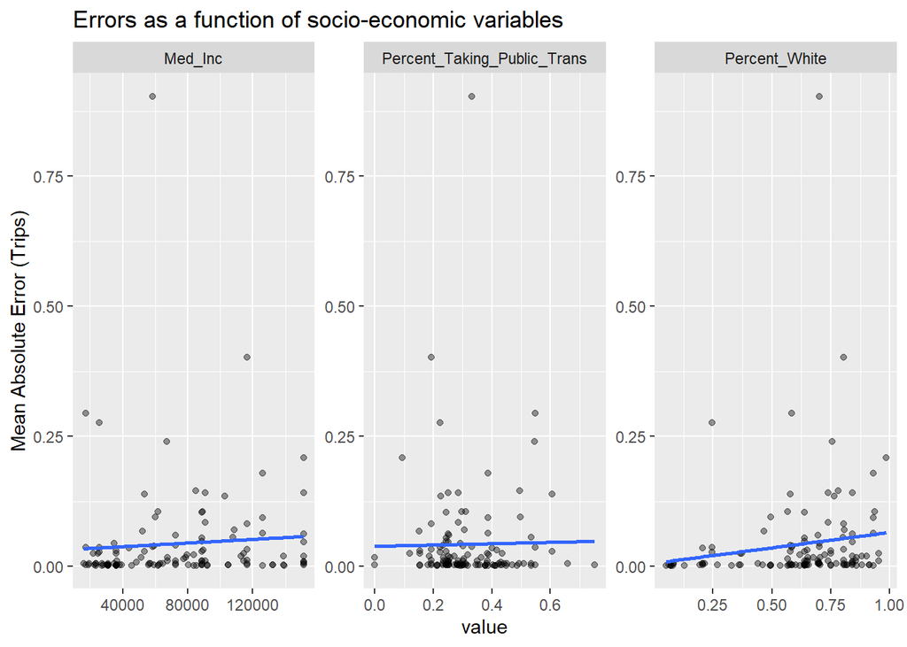